# NYPD Shooting Inicident Data Historic

Steven Hobbs

2024-10-14

## Data Import and Wrangling

```r
nypd <- read_csv("NYPD_Shooting_Incident_Data__Historic_.csv")

names(nypd) = c('key', 'date', 'time', 'borough', 'location', 'precinct', 'jcode', 'loc_class', 'loc_desc', 'sm_flag', 'perp_age', 'perp_sex', 'perp_race', 'vic_age', 'vic_sex', 'vic_race', 'xcoord', 'ycoord', 'lat', 'long', 'lon_lat')

nypd <-
    nypd %>%
    # change all character variables to factors
    mutate(across(where(is.character), as.factor),
           date = mdy(date),
           day = day(date),
           month = month(date),
           year = year(date),

           vic_age = fct_relevel(vic_age, "<18", "18-24",
                                 "25-44", "45-64", "65+"),
           vic_age = replace(vic_age, vic_age %in% c("1022", "UNKNOWN"), NA),
           vic_sex = replace(vic_sex, vic_sex %in% c("U", "(null)"), NA),
           vic_race = na_if(vic_race, c("UNKNOWN")),

           perp_age = fct_relevel(perp_age, "<18", "18-24",
                                  "25-44", "45-64", "65+"),
           perp_age = replace(perp_age, perp_age %in% c("UNKNOWN", "224", "940", "1020", "1028", "(null)", "(Other)"), NA),

           perp_sex = replace(perp_sex, perp_sex %in% c("U", "(null)"), NA),
           perp_race = replace(perp_race, perp_race %in% c("(null)", "UNKNOWN", "(Other)"), NA),

           across(c(perp_age, perp_sex, perp_race, vic_age, vic_sex, vic_race), droplevels)
           ) |>
    select(time, day, month, date, year, borough, precinct, perp_age:vic_race)
```

## Inspect Data

```r
nypd |>
    select(1:5) |>
    summary() |> kable() |> kable_classic()
```

|  | time | day | month | date | year |
| --- | --- | --- | --- | --- | --- |
|  | Length:28562 | Min. : 1.00 | Min. : 1.000 | Min. :2006-01-01 | Min. :2006 |
|  | Class1:hms | 1st Qu.: 8.00 | 1st Qu.: 5.000 | 1st Qu.:2009-09-04 | 1st Qu.:2009 |
|  | Class2:difftime | Median :16.00 | Median : 7.000 | Median :2013-09-20 | Median :2013 |
|  | Mode :numeric | Mean :15.92 | Mean : 6.805 | Mean :2014-06-07 | Mean :2014 |
|  | NA | 3rd Qu.:24.00 | 3rd Qu.: 9.000 | 3rd Qu.:2019-09-29 | 3rd Qu.:2019 |
|  | NA | Max. :31.00 | Max. :12.000 | Max. :2023-12-29 | Max. :2023 |

```r
nypd |>
    select(6:10) |>
    summary() |> kable() |> kable_classic()
```

|  | borough | precinct | perp_age | perp_sex | perp_race |
| --- | --- | --- | --- | --- | --- |
|  | BRONX : 8376 | Min. : 1.0 | <18 : 1682 | F : 444 | AMERICAN INDIAN/ALASKAN NATIVE: 2 |
|  | BROOKLYN :11346 | 1st Qu.: 44.0 | 18-24: 6438 | M :16168 | ASIAN / PACIFIC ISLANDER : 169 |
|  | MANHATTAN : 3762 | Median : 67.0 | 25-44: 6041 | NA’s:11950 | BLACK :11903 |
|  | QUEENS : 4271 | Mean : 65.5 | 45-64: 699 | NA | BLACK HISPANIC : 1392 |
|  | STATEN ISLAND: 807 | 3rd Qu.: 81.0 | 65+ : 65 | NA | WHITE : 298 |
|  | NA | Max. :123.0 | NA’s :13637 | NA | WHITE HISPANIC : 2510 |
|  | NA | NA | NA | NA | NA’s :12288 |

```r
nypd |>
    select(11:13) |>
    summary() |> kable() |> kable_classic()
```

|  | vic_age | vic_sex | vic_race |
| --- | --- | --- | --- |
|  | <18 : 2954 | F : 2760 | AMERICAN INDIAN/ALASKAN NATIVE: 11 |
|  | 18-24:10384 | M :25790 | ASIAN / PACIFIC ISLANDER : 440 |
|  | 25-44:12973 | NA’s: 12 | BLACK :20235 |
|  | 45-64: 1981 | NA | BLACK HISPANIC : 2795 |
|  | 65+ : 205 | NA | WHITE : 728 |
|  | NA’s : 65 | NA | WHITE HISPANIC : 4283 |
|  | NA | NA | NA’s : 70 |

## Shootings in New York by Borough

[figure not shown]

```r
nypd %>%
    group_by(borough, year, month) %>%
    summarize(shootings = n()) %>%
    mutate(date2 = make_date(year, month)) %>%
    ggplot(aes(x = date2, y = shootings, color = borough)) +
    geom_point() +
    geom_smooth(method = "loess", formula = 'y~x', se = FALSE) +
    geom_vline(xintercept = as.Date("2020-01-01"), color = "black") +
    annotate(geom = "text", x = as.Date("2020-01-01"), y = 200,
             label = "COVID-19 \n in U.S. ", hjust = "right") +
    geom_vline(xintercept = as.Date("2015-06-01"), color = "black") +
    annotate(geom = "text", x = as.Date("2015-06-01"), y = 200,
             label = "2016 \n Presidential \n Campaigns \n Begin ",
             hjust = "right") +
    scale_color_discrete(name = "Borough",
                         labels = c("Brooklyn", "Queens", "Bronx",
                                    "Manhattan", "Staten Island")) +
    labs(x = "Year", y = "Monthly Shootings") +
    theme_classic() +
    theme(legend.position = c(.15, .8)) +
    theme(legend.box.background = element_rect(color = "black", linewidth = 1),
    legend.box.margin = margin(5, 5, 5, 5))
```

## Shootings in New York Boroughs by Age

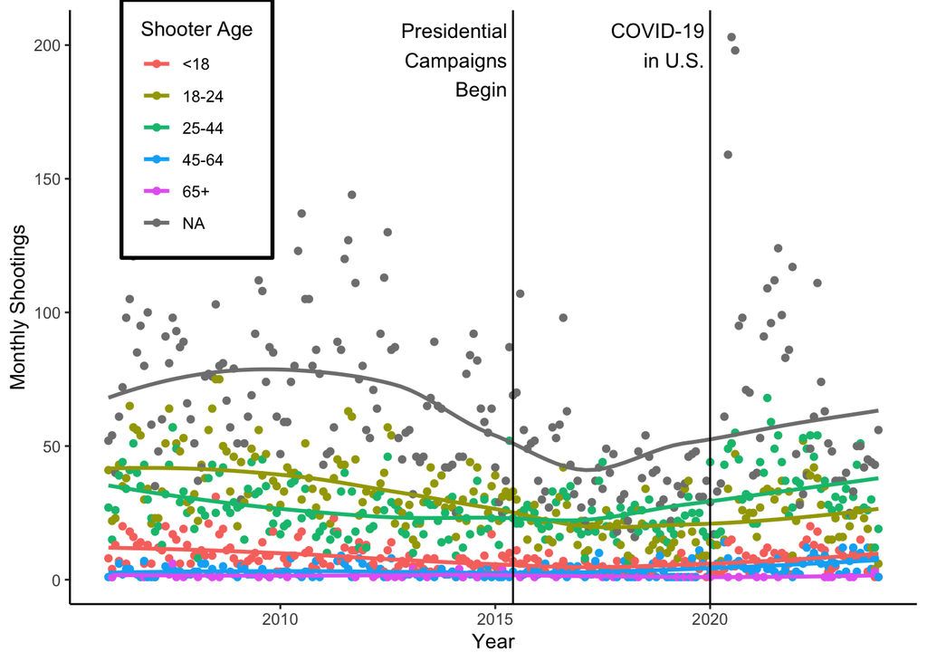

```r
nypd %>%
    filter(!(perp_age %in% c("", "UNKNOWN", "1020", "940", "224"))) %>%
    droplevels %>%
    group_by(year, month, perp_age) %>%
    summarize(shootings = n()) %>%
    mutate(date2 = make_date(year, month)) %>%
    ggplot(aes(x = date2, y = shootings, color = perp_age)) +
    geom_point() +
    geom_smooth(method = "loess", formula = 'y~x', se = FALSE) +
    geom_vline(xintercept = as.Date("2020-01-01"), color = "black") +
    annotate(geom = "text", x = as.Date("2020-01-01"), y = 200,
             label = "COVID-19 \n in U.S. ", hjust = "right") +
    geom_vline(xintercept = as.Date("2015-06-01"), color = "black") +
    annotate(geom = "text", x = as.Date("2015-06-01"), y = 200,
             label = "2016 \n Presidential \n Campaigns \n Begin ",
             hjust = "right") +
    scale_color_discrete(name = "Shooter Age") +
    labs(x = "Year", y = "Monthly Shootings") +
    theme_classic() +
    theme(legend.position = c(.15, .8)) +
    theme(legend.box.background = element_rect(color = "black", linewidth = 1),
    legend.box.margin = margin(5, 5, 5, 5))
```

## Shootings in New York Boroughs by Shooter Race

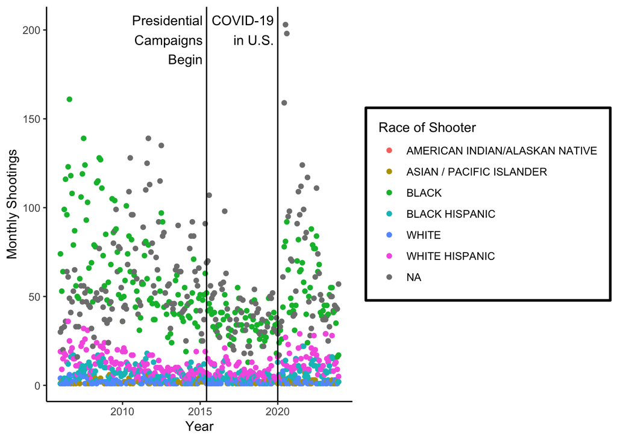

```r
nypd %>%
    filter(!(perp_race %in% c("", "UNKNOWN"))) %>%
    droplevels %>%
    group_by(year, month, perp_race) %>%
    summarize(shootings = n()) %>%
    mutate(date2 = make_date(year, month)) %>%
    ggplot(aes(x = date2, y = shootings, color = perp_race)) +
    geom_point() +
    # geom_smooth(method = "loess", formula = 'y~x', se = FALSE) +
    # Insufficient data for smooth curves in most groups.
    geom_vline(xintercept = as.Date("2020-01-01"), color = "black") +
    annotate(geom = "text", x = as.Date("2020-01-01"), y = 200,
             label = "COVID-19 \n in U.S. ", hjust = "right") +
    geom_vline(xintercept = as.Date("2015-06-01"), color = "black") +
    annotate(geom = "text", x = as.Date("2015-06-01"), y = 200,
             label = "2016 \n Presidential \n Campaigns \n Begin ",
             hjust = "right") +
    scale_color_discrete(name = "Race of Shooter") +
    labs(x = "Year", y = "Monthly Shootings") +
    theme_classic() +
    theme(legend.box.background = element_rect(color = "black", linewidth = 1),
          legend.box.margin = margin(5, 5, 5, 5))
```

# Shootings in New York Boroughs by Sex

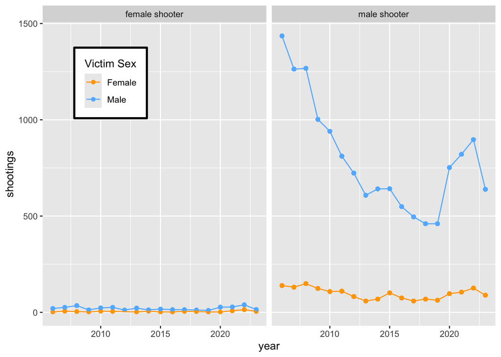

```r
nypd_sex <-
    nypd %>%
    filter(vic_sex != "U", perp_sex == "M" | perp_sex == "F",
           !(perp_age %in% c("1020", "940", "224", "UNKNOWN", ""))) %>%
    mutate(perp_sex = fct_recode(perp_sex,
                                  "male shooter" = "M",
                                  "female shooter" = "F"),
           perp_sex = fct_relevel(perp_sex, 'female shooter'),
           vic_sex = fct_relevel(vic_sex, 'F')) %>%
    droplevels %>%
    group_by(year, perp_sex, vic_sex) %>%
    mutate(shootings = n()) %>%
    ungroup %>%
    group_by(year) %>%
    mutate(year_total = sum(shootings)) %>%
    ungroup %>%
    select(year, perp_sex, vic_sex, perp_age, vic_age, shootings, year_total)

nypd_sex %>%
    ggplot(aes(x = year)) +
    geom_point(aes(y = shootings, color = vic_sex)) +
    geom_line(aes(y = shootings, color = vic_sex)) +
    scale_color_manual(name = "Victim Sex",
                       values = c("orange", "steelblue1"),
                       labels = c("Female", "Male")) +
    facet_wrap(~ perp_sex) +
    theme(legend.position = c(.15, .8)) +
    theme(legend.box.background = element_rect(color = "black", linewidth = 1),
    legend.box.margin = margin(5, 5, 5, 5))
```

## Shootings in New York Boroughs Within (intra) and Across (inter) Racial Groups.

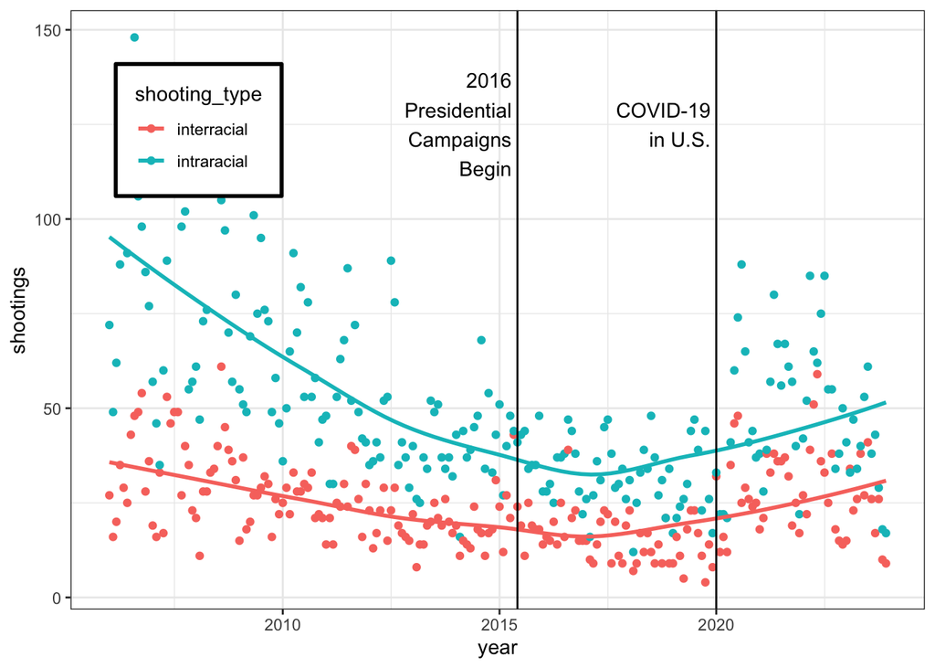

```r
nypd %>%
    filter(perp_race != "", perp_race != "UNKNOWN", vic_race != "UNKNOWN") %>%
    droplevels %>%
    mutate(shooting_type = ifelse(perp_race == vic_race,
                                  "intraracial",
                                  "interracial"),
           date2 = make_date(year, month)) %>%
    group_by(date2, shooting_type) %>%
    summarize(shootings = n()) %>%
    ggplot(aes(x = date2, y = shootings, color = shooting_type)) +
    geom_point() +
    geom_smooth(method = 'loess', formula = y~x, se = FALSE) +
    geom_vline(xintercept = as.Date("2020-01-01"), color = "black") +
    annotate(geom = "text", x = as.Date("2020-01-01"), y = 125,
             label = "COVID-19 \n in U.S. ", hjust = "right") +
    geom_vline(xintercept = as.Date("2015-06-01"), color = "black") +
    annotate(geom = "text", x = as.Date("2015-06-01"), y = 125,
             label = "2016 \n Presidential \n Campaigns \n Begin ",
             hjust = "right") +
    labs(x = "year", y = "shootings") +
    theme_bw() +
    theme(legend.position = c(.15, .8)) +
    theme(legend.box.background = element_rect(color = "black", linewidth = 1),
    legend.box.margin = margin(5, 5, 5, 5))
```

## Logistic regression model predicting victim sex from shooter and victim ages.

```r
model <-
    nypd_sex %>%
    mutate(vic_sex = fct_relevel(vic_sex, "M")) %>% # Make "F" the predicted sex
    filter(vic_age != "UNKNOWN") %$%
    glm(vic_sex ~ perp_sex + perp_age + vic_age,
         family = binomial(logit))

summary(model)
```

```
##
## Call:
## glm(formula = vic_sex ~ perp_sex + perp_age + vic_age, family = binomial(logit))
##
## Coefficients:
##                      Estimate Std. Error z value Pr(>|z|)
## (Intercept)          -1.03978    0.15715  -6.617 3.68e-11 ***
## perp_sexmale shooter -0.49521    0.13367  -3.705 0.000212 ***
## perp_age18-24        -0.05488    0.08795  -0.624 0.532615
## perp_age25-44         0.11649    0.09089   1.282 0.199957
## perp_age45-64         0.51002    0.13020   3.917 8.96e-05 ***
## perp_age65+           1.71462    0.27308   6.279 3.41e-10 ***
## vic_age18-24         -0.86649    0.08375 -10.347  < 2e-16 ***
## vic_age25-44         -0.75658    0.08175  -9.254  < 2e-16 ***
## vic_age45-64          0.01916    0.10336   0.185 0.852952
## vic_age65+            0.64303    0.19988   3.217 0.001295 **
## ---
## Signif. codes:  0 '***' 0.001 '**' 0.01 '*' 0.05 '.' 0.1 ' ' 1
##
## (Dispersion parameter for binomial family taken to be 1)
##
##     Null deviance: 10609  on 14838  degrees of freedom
## Residual deviance: 10280  on 14829  degrees of freedom
##   (1712 observations deleted due to missingness)
## AIC: 10300
##
## Number of Fisher Scoring iterations: 5
```

## Predicting victim sex for male and female shooters across age levels

```r
# Predict the probability that the victim is male for perp_sex = "male shooter" across all levels of perp_age and vic_age
male_shooters = data.frame(perp_sex = rep("male shooter", 9),
                           perp_age = rep(levels(nypd_sex$vic_age)[1:3]), 3,
                           vic_age = c(rep("<18", 3), rep("18-24", 3), rep("25-44", 3)))

temp_m = predict(model, newdata = male_shooters, type = "response") |> round(2)
temp_m = matrix(temp_m, nrow = 3, ncol = 3, byrow = TRUE)
colnames(temp_m) = paste("Perp Age", levels(nypd_sex$perp_age)[1:3])
rownames(temp_m) = paste("Vic Age", levels(nypd_sex$vic_age)[1:3])
temp_m |>
    kable(caption = "The Probability of a Female Victim for Male Shooters by age") |>
    kable_classic(full_width = F)
```

The Probability of a Female Victim for Male Shooters by age

|  | Perp Age <18 | Perp Age 18-24 | Perp Age 25-44 |
| --- | --- | --- | --- |
| Vic Age <18 | 0.18 | 0.17 | 0.19 |
| Vic Age 18-24 | 0.08 | 0.08 | 0.09 |
| Vic Age 25-44 | 0.09 | 0.09 | 0.10 |

```r
# Predict the probability that the victim is female for perp_sex = "female shooter" across all levels of perp_age and vic_age
female_shooters = data.frame(perp_sex = rep("female shooter", 9),
                             perp_age = rep(levels(nypd_sex$vic_age)[1:3]), 3,
                             vic_age = c(rep("<18", 3), rep("18-24", 3), rep("25-44", 3)))

temp_f = predict(model, newdata = female_shooters, type = "response") |> round(2)
temp_f = matrix(temp_f, nrow = 3, ncol = 3, byrow = TRUE)
colnames(temp_f) = paste("Perp Age", levels(nypd_sex$perp_age)[1:3])
rownames(temp_f) = paste("Vic Age", levels(nypd_sex$vic_age)[1:3])
temp_f |> kable(caption = "The Probability of a Female Victim for Female Shooters by age") |> kable_classic(full_width = F)
```

The Probability of a Female Victim for Female Shooters by age

|  | Perp Age <18 | Perp Age 18-24 | Perp Age 25-44 |
| --- | --- | --- | --- |
| Vic Age <18 | 0.26 | 0.25 | 0.28 |
| Vic Age 18-24 | 0.13 | 0.12 | 0.14 |
| Vic Age 25-44 | 0.14 | 0.14 | 0.16 |

```r
# Find the Odds ratio comparing the odds of a female victim for female perps to the odds of a female victim for male perps
OR = exp(coef(model)["perp_sexmale shooter"])^-1 |> round(2)
names(OR) = "Female perpetrator / Male perpetrator"
OR |> kable(col.names = "OR", caption = "Female Victim Odds Ratio") |> kable_classic(full_width = F)
```

Female Victim Odds Ratio

|  | OR |
| --- | --- |
| Female perpetrator / Male perpetrator | 1.64 |

## Conclusions

Most shooting perpetrators were in the 18-24 and 25-44 age groups. In the late 2000’s and early 2010’s perpetrator rates were decreasing in both of these groups, but more dramatically for the youngest age group, 18-24. In the late 2010’s and early 2020’s shooting perpetrator rates increased in both groups, but this trend was stronger for the 25-44 age group, which took over as the highest rate group in late 2015.

Most shootings in New York boroughs were perpetrated by black men. However, these data do not contain population demographic or economic data, meaning we can not determine if, for example, the shooting rate per 1000 persons is comparable or different across the races, and we cannot determine how poverty and prosperity connect with shooting rates.

No obvious linear relationships were present, so I created a logistic regression model to explore if victim sex could be predicted from perpetrator sex, perpetrator age, and victim age. I created a prediction matrix for male and female perpetrators and the first three age groups. The last two age groups were ignored due to low sample size.

The results show that females are less likely to be victims of shootings at all ages and regardless of the perpetrator sex. However, female victims are about twice as common in the youngest age group, <18, compared to the older age groups. This trend is consistent across all perpetrator ages and for both male and female perpetrators. Additionally, the odds of a female victim are about 1.6 times higher for female perpetrators compared to male perpetrators.

A limitation imposed by the dataset is that suicides are not identifiable. In some cases the perpetrator and the victim may be the same individual. Additionally, the sample sizes in some groups may be very small, such that even very small P-values may represent spurious false positive relationships. While further analysis, could verify sample sizes, it’s time to wrap up this analysis and move on in the course!

Upon beginning this analysis, I was expecting to see an increase in shootings after the COVID-19 pandemic took hold in the spring of 2020 and I was expecting the 18-24 year old age group to be responsible for the uptick. I mitigated these biases by retaining all the data from all New York boroughs. The only data not included in any given figure are data with missing or erroneous values directly related to the plot. Also, the data have been minimally processed, and everything I’ve done to the data is fully transparent in this document.